# Projeto K-Means Pokemon

# Gráfico dos pokemon ataque

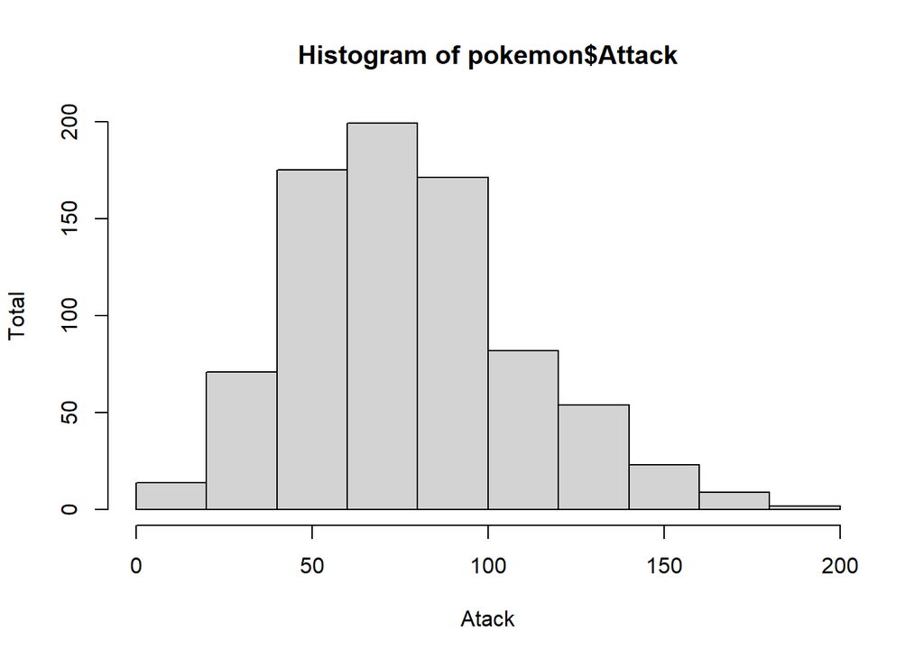

```r
hist(pokemon$Attack,
     xlab = "Atack",
     ylab = "Total",
     title = "Atack dos pokemon")
```

# Gráfico dos pokemon defesa

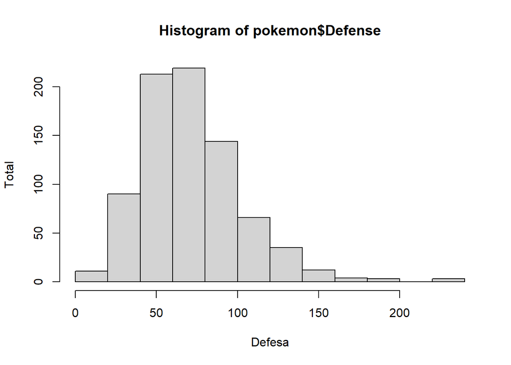

```r
hist(pokemon$Defense,
     xlab = "Defesa",
     ylab = "Total",
     title = "Defesa dos pokemon")
```

# Gráfico boxplot dos pokemon

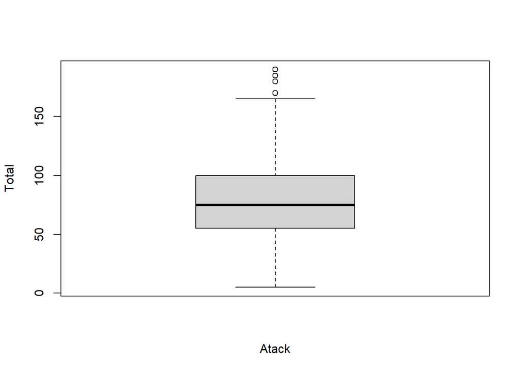

```r
boxplot(pokemon $Attack,
        xlab = "Atack",
        ylab = "Total",
        title = "Atack dos pokemon")
```

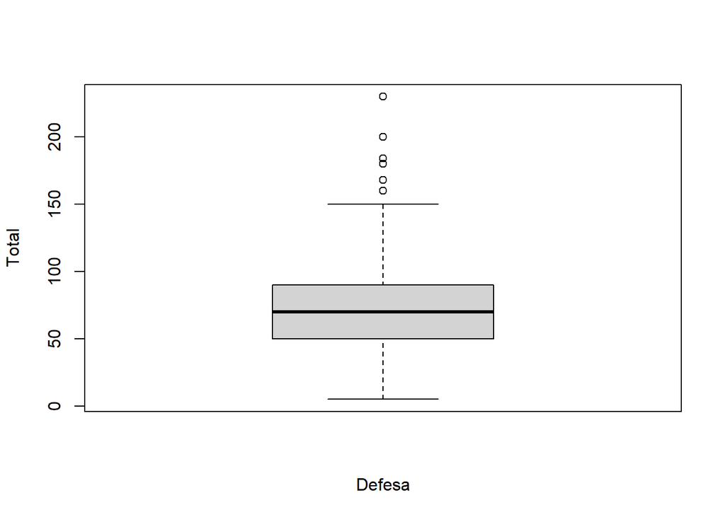

```r
boxplot(pokemon$Defense,
        xlab = "Defesa",
        ylab = "Total",
        title = "Defesa dos pokemon")
```

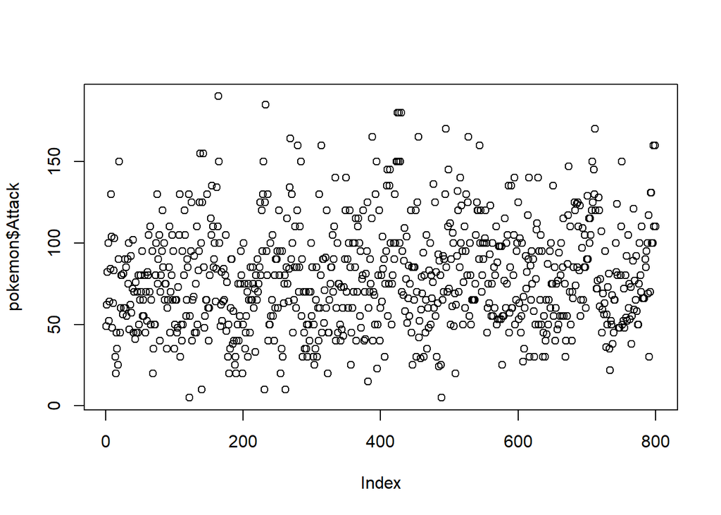

```r
plot(pokemon$Attack)
```

# Inicialize o total dentro do erro da soma dos quadrados: wss

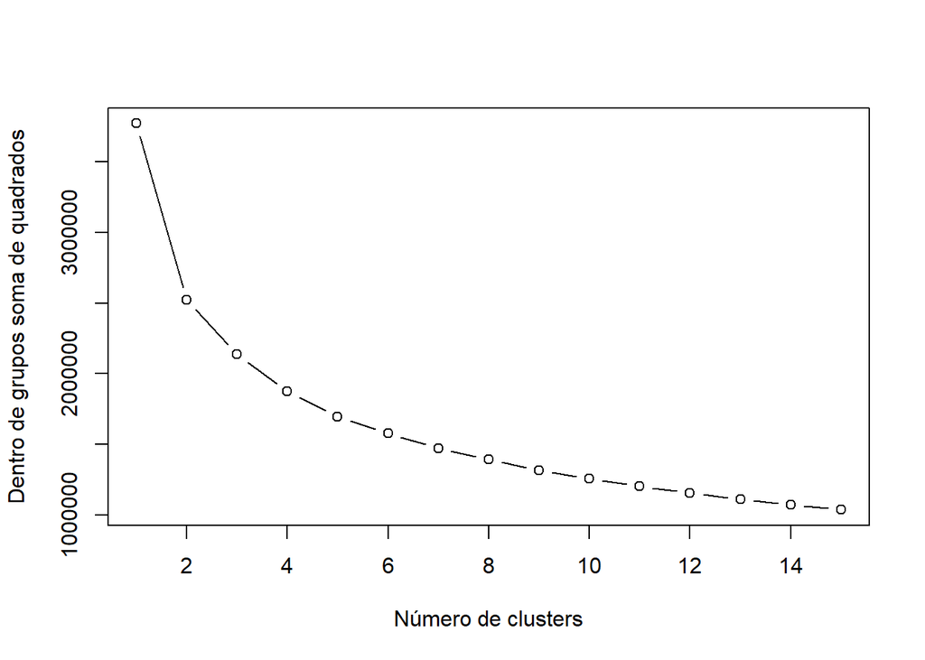

```r
wss <- 0

# Veja de 1 a 15 clusters possíveis
for (i in 1:15) {
  # Ajuste o modelo: km.out
  km.out <- kmeans(pokemon, centers = i, nstart = 20, iter.max = 50)

  # Salve a soma dos quadrados dentro do cluster
  wss[i] <- km.out$tot.withinss
}

# Produza um scree plot
plot(1:15, wss, type = "b",
     xlab = "Número de clusters",
     ylab = "Dentro de grupos soma de quadrados")
```

# Selecione o número de clusters

```r
k <- 10

# Construir modelo com k clusters: km.out
km.pokemon <- kmeans(pokemon, centers = k, nstart = 20, iter.max = 50)

# Visualize o modelo resultante
km.pokemon
```

```
## K-means clustering with 10 clusters of sizes 98, 54, 23, 34, 94, 91, 71, 106, 124, 105
##
## Cluster means:
##       Attack   Defense   Sp. Atk   Sp. Def    Speed Generation
## 1   70.10204  74.78571  45.15306  54.15306 38.26531   3.520408
## 2  140.77778  93.96296 131.12963  92.92593 98.62963   3.685185
## 3   68.04348 137.21739  67.60870 138.69565 50.69565   3.869565
## 4  106.14706 145.02941  62.35294  68.88235 46.14706   3.147059
## 5  116.43617  87.14894  61.56383  77.94681 82.28723   3.297872
## 6   37.19780  41.76923  40.42857  47.31868 40.84615   3.109890
## 7   80.91549  85.92958 120.64789 105.09859 95.76056   3.211268
## 8   79.42453  64.03774  83.29245  69.52830 99.99057   3.339623
## 9   62.20161  45.15323  56.26613  48.78226 66.56452   3.225806
## 10  69.98095  77.17143  87.97143  87.15238 54.35238   3.276190
##
```

[output cut: 43 more lines]

# Plot of Defense vs. Speed por associação de cluster

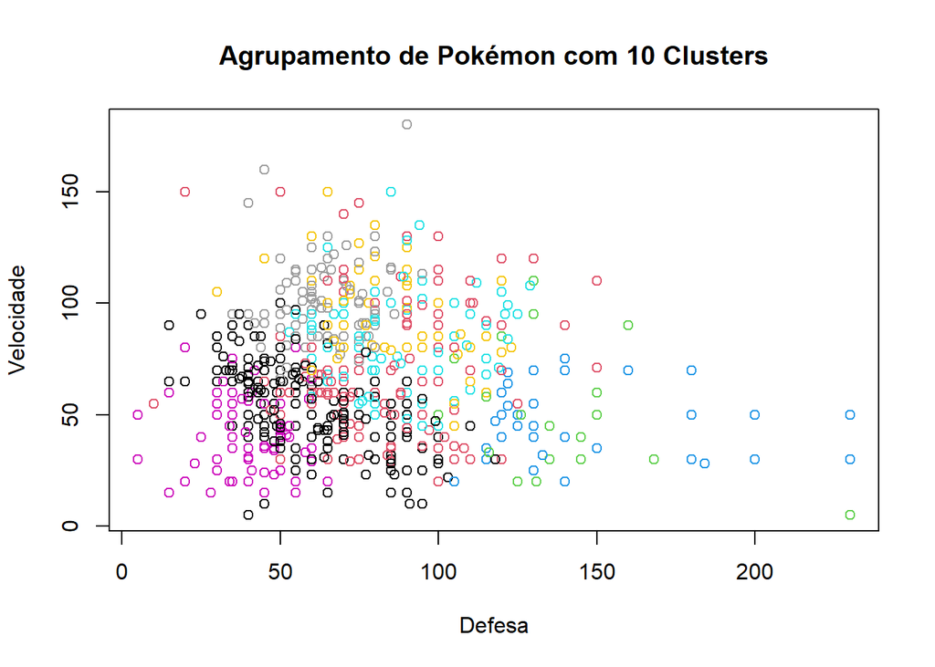

```r
plot(pokemon[, c("Defense", "Speed")],
     col = km.pokemon$cluster,
     main = paste("Agrupamento de Pokémon com", k, "Clusters"),
     xlab = "Defesa", ylab = "Velocidade")
```

```r
# Ver os meios da coluna
colMeans(pokemon)
```

```
##     Attack    Defense    Sp. Atk    Sp. Def      Speed Generation
##   79.00125   73.84250   72.82000   71.90250   68.27750    3.32375
```

```r
# Veja os desvios padrão da coluna
apply(pokemon, 2, sd)
```

```
##     Attack    Defense    Sp. Atk    Sp. Def      Speed Generation
##   32.45737   31.18350   32.72229   27.82892   29.06047    1.66129
```

```r
# Dimensionar os dados
pokemon.scaled <- scale(pokemon)

# Crie um modelo de cluster hierárquico: hclust.pokemon
hclust.pokemon <- hclust(dist(pokemon.scaled), method = "complete")
```

# Comparando kmeans() e hclust()

```r
# Aplique cutree() ao hclust.pokemon: cut.pokemon
cut.pokemon <- cutree(hclust.pokemon, k = 3)

# Comparar métodos
table(km.pokemon$cluster, cut.pokemon)
```

```
##     cut.pokemon
##        1   2   3
##   1   98   0   0
##   2   47   7   0
##   3   22   0   1
##   4   34   0   0
##   5   94   0   0
##   6   91   0   0
##   7   61  10   0
##   8  103   3   0
##   9  124   0   0
##   10 105   0   0
```

```r
pokemon
```

```
## # A tibble: 800 x 6
##    Attack Defense `Sp. Atk` `Sp. Def` Speed Generation
##     <dbl>   <dbl>     <dbl>     <dbl> <dbl>      <dbl>
##  1     49      49        65        65    45          1
##  2     62      63        80        80    60          1
##  3     82      83       100       100    80          1
##  4    100     123       122       120    80          1
##  5     52      43        60        50    65          1
##  6     64      58        80        65    80          1
##  7     84      78       109        85   100          1
##  8    130     111       130        85   100          1
##  9    104      78       159       115   100          1
## 10     48      65        50        64    43          1
## # ... with 790 more rows
```

# PCA

- Estamos usando apenas 4 variáveis do conjunto de dados pokemon aqui

```r
pokemon_pr <- data %>% select(HP, Attack, Defense, Speed)
glimpse(pokemon_pr)
```

```
## Rows: 800
## Columns: 4
## $ HP      <dbl> 45, 60, 80, 80, 39, 58, 78, 78, 78, 44, 59, 79, 79, 45, 50, 60~
## $ Attack  <dbl> 49, 62, 82, 100, 52, 64, 84, 130, 104, 48, 63, 83, 103, 30, 20~
## $ Defense <dbl> 49, 63, 83, 123, 43, 58, 78, 111, 78, 65, 80, 100, 120, 35, 55~
## $ Speed   <dbl> 45, 60, 80, 80, 65, 80, 100, 100, 100, 43, 58, 78, 78, 45, 30,~
```

```r
summary(pokemon_pr)
```

```
##        HP             Attack       Defense           Speed
##  Min.   :  1.00   Min.   :  5   Min.   :  5.00   Min.   :  5.00
##  1st Qu.: 50.00   1st Qu.: 55   1st Qu.: 50.00   1st Qu.: 45.00
##  Median : 65.00   Median : 75   Median : 70.00   Median : 65.00
##  Mean   : 69.26   Mean   : 79   Mean   : 73.84   Mean   : 68.28
##  3rd Qu.: 80.00   3rd Qu.:100   3rd Qu.: 90.00   3rd Qu.: 90.00
##  Max.   :255.00   Max.   :190   Max.   :230.00   Max.   :180.00
```

```r
pr.pokemon <- prcomp(x = pokemon_pr, scale = T, center = T)
summary
```

```
## function (object, ...)
## UseMethod("summary")
## <bytecode: 0x00000000216ff0a8>
## <environment: namespace:base>
```

```r
pr.pokemon
```

```
## Standard deviations (1, .., p=4):
## [1] 1.3721424 0.9932783 0.8526020 0.6353685
##
## Rotation (n x k) = (4 x 4):
##               PC1         PC2        PC3        PC4
## HP      0.5009303 -0.06463396  0.8300858 -0.2363236
## Attack  0.6301797  0.02703796 -0.1621455  0.7588487
## Defense 0.4556878 -0.61865282 -0.4521283 -0.4529871
## Speed   0.3798566  0.78253440 -0.2832778 -0.4038596
```

# Resultados do PCA

Os modelos PCA produzem componentes adicionais de diagnóstico e saída:

- Center - o meio da coluna usado para centralizar os dados
- Scale - a coluna sd usada para dimensionar os dados
- Rotacao - a direcao dos vetores prin comp em termos das feições/variáveis originais. Essas informações de alguma forma permitem que você defina novos

Dados em termos dos componentes principais originais. - x - o valor de cada observação no conjunto de dados original projetado para os componentes principais

```r
pr.pokemon$center
```

```
##       HP   Attack  Defense    Speed
## 69.25875 79.00125 73.84250 68.27750
```

```r
pr.pokemon$scale
```

```
##       HP   Attack  Defense    Speed
## 25.53467 32.45737 31.18350 29.06047
```

```r
pr.pokemon$rotation
```

```
##               PC1         PC2        PC3        PC4
## HP      0.5009303 -0.06463396  0.8300858 -0.2363236
## Attack  0.6301797  0.02703796 -0.1621455  0.7588487
## Defense 0.4556878 -0.61865282 -0.4521283 -0.4529871
## Speed   0.3798566  0.78253440 -0.2832778 -0.4038596
```

```r
head(pr.pokemon$x,10)
```

```
##              PC1          PC2         PC3          PC4
##  [1,] -1.7256845 -0.097546271 -0.05163582  0.207456766
##  [2,] -0.7783645  0.001484139  0.02184005 -0.039259320
##  [3,]  0.5559879  0.109293957  0.08715421 -0.325236471
##  [4,]  1.4899932 -0.669275804 -0.58272583 -0.485458941
##  [5,] -1.6113972  0.577730653 -0.36963560  0.142341152
##  [6,] -0.5904092  0.645964030 -0.17563029 -0.179301322
##  [7,]  0.7439432  0.753773847 -0.11031614 -0.465278473
##  [8,]  2.1192939  0.137402684 -0.81858156  0.130820647
##  [9,]  1.1322555  0.770434451 -0.21022907  0.002318739
## [10,] -1.5570505 -0.467129383 -0.29163598 -0.011297649
```

# Interpretando biplots (1)

- Quais duas variáveis originais têm aproximadamente as mesmas cargas nos dois primeiros componentes principais?
- Pontos de Ataque e Vida (HP)
- Quais dois pokémons são os menos semelhantes em termos do segundo componente principal?
  - 430 e 231 (pontos mais altos e mais baixos)
  - Posso usar os ids para pesquisar o nome no conjunto de dados original

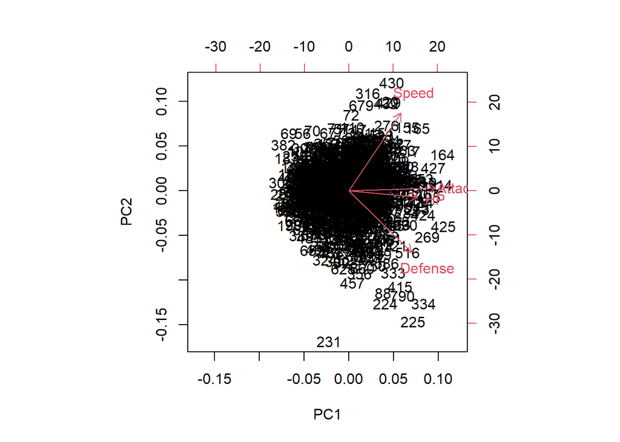

```r
biplot(pr.pokemon)
```

# Variação explicada

```r
# Variabilidade de cada componente principal: pr.var
pr.var <- pr.pokemon$sdev^2

# Variação explicada por cada componente principal: pve
pve <- pr.var / sum(pr.var)
pve
```

```
## [1] 0.4706937 0.2466505 0.1817326 0.1009233
```

# Visualizar variação explicada

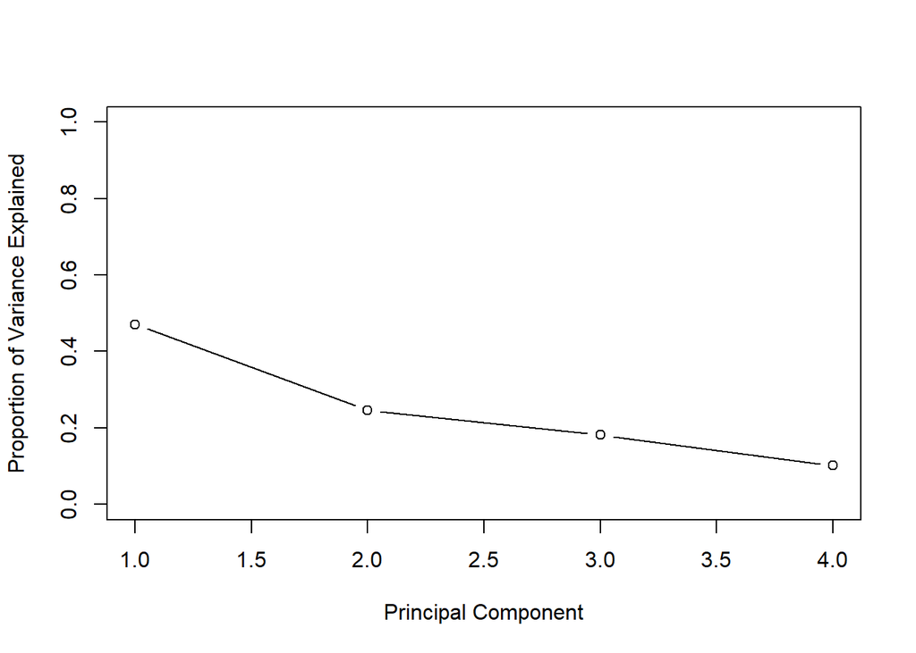

```r
# Variação do gráfico explicada para cada componente principal

plot(pve, xlab = "Principal Component",
     ylab = "Proportion of Variance Explained",
     ylim = c(0, 1), type = "b")
```

# Plotar proporção cumulativa de variância explicada

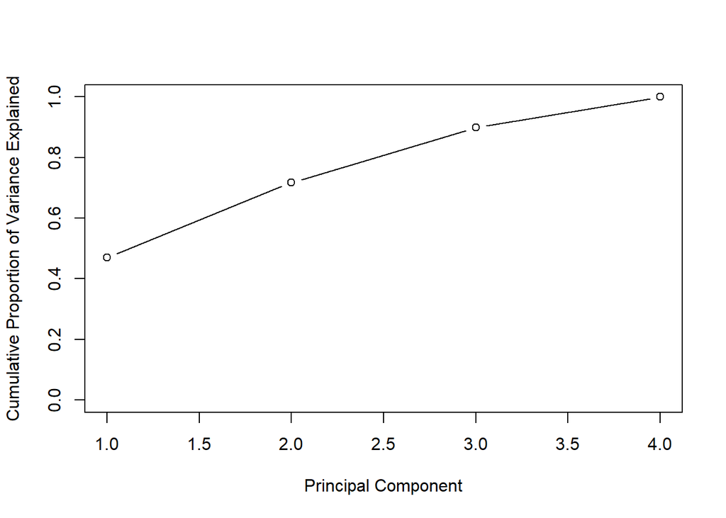

```r
plot(cumsum(pve), xlab = "Principal Component",
     ylab = "Cumulative Proportion of Variance Explained",
     ylim = c(0, 1), type = "b")
```

```r
# Média de cada variável
colMeans(pokemon_pr)
```

```
##       HP   Attack  Defense    Speed
## 69.25875 79.00125 73.84250 68.27750
```

```r
# Desvio padrão de cada variável
apply(pokemon_pr, 2, sd)
```

```
##       HP   Attack  Defense    Speed
## 25.53467 32.45737 31.18350 29.06047
```

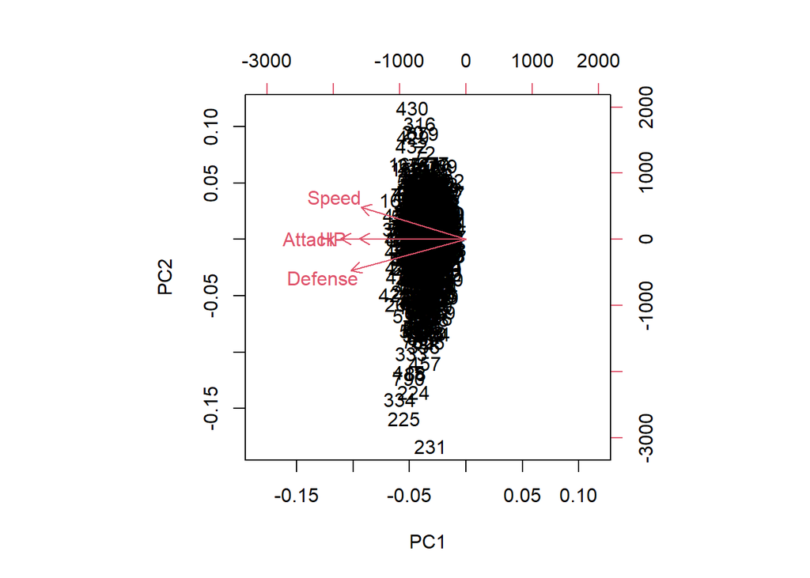

```r
# Modelo PCA com dimensionamento: pr.with.scaling
pr.with.scaling <- prcomp(pokemon_pr, scale = T, center = T)

# Modelo PCA sem dimensionamento: pr.without.scaling
pr.without.scaling <- prcomp(pokemon_pr, scale = F, center = F)

# Cria biplots de ambos para comparação
biplot(pr.without.scaling)
```

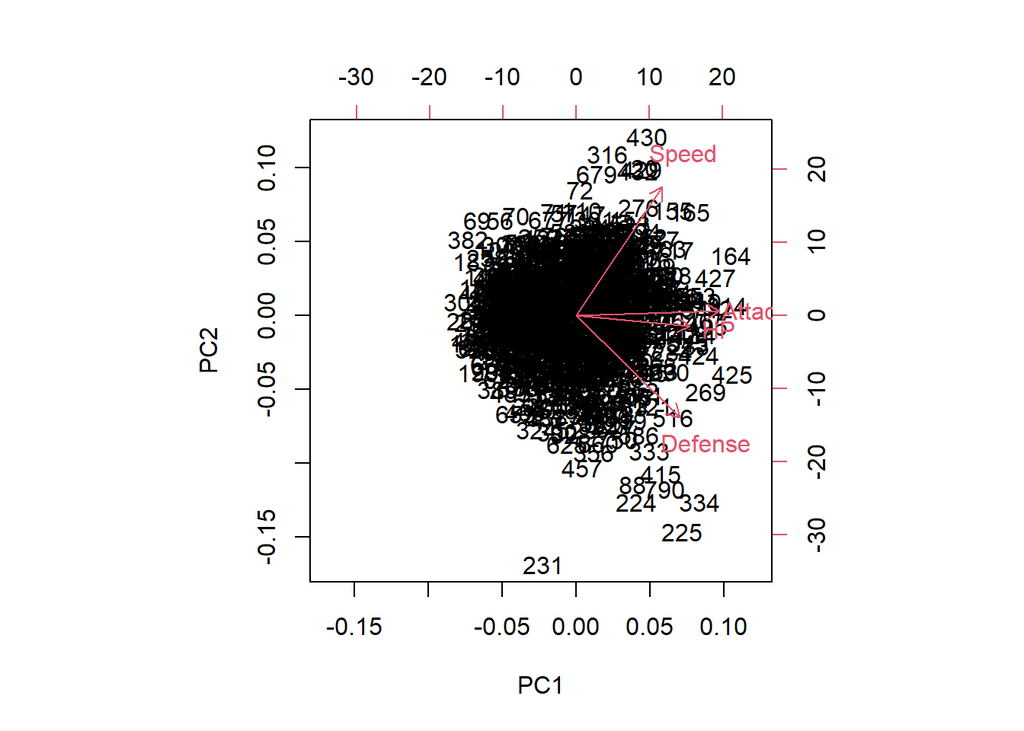

```r
biplot(pr.with.scaling)
```